# Guidelines interpretation GORIC(A) benchmark output

### 3.2.1 Higher sample size

```r
# Now, group size is 200 (instead of 40)

# H1 vs complement (default)
H1 <- "D1 > D2 > D3" # mu1 > mu2 > mu3

# Apply GORIC #
set.seed(123)
results_1c_200 <- goric(fit_200, hypotheses = list(H1))
results_1c_200
```

```
## restriktor (0.6-50): generalized order-restricted information criterion:
##
## Results:
##         model    loglik  penalty     goric  loglik.weights  penalty.weights  goric.weights
## 1          H1  -829.928    2.833  1665.522           0.889            0.697          0.949
## 2  complement  -832.009    3.667  1671.351           0.111            0.303          0.051
##
## Conclusion:
## The order-restricted hypothesis 'H1' has 18.43 times more support than its complement.
```

Also here, we will check whether there is support for the border of the two (non-overlapping) hypotheses:

```r
# Specifying multiple null populations, that is,
# using all possibilities of setting inequalities to equalities.
# Here, we will use the default `model_type` (i.e., "asymp") which takes population parameter values (instead of population effect sizes)
est <- coef(fit_200)
pop_est <- matrix(c(
                  mean(est[1:3]), mean(est[1:3]), mean(est[1:3]),
                  mean(est[1:2]), mean(est[1:2]), est[3],
                  mean(est[1:2]), est[2], mean(est[1:2]),
                  est[1], mean(est[2:3]), mean(est[2:3]),

                  est[1], est[2], est[3]
                  ),
                  byrow = TRUE, ncol = length(est))
rownames(pop_est) <- c("PE_123eq", "PE_12eq", "PE_13eq", "PE_23eq", "Observed")
#
set.seed(123)
benchmarks_1c_allpos_200 <- benchmark(results_1c_200, pop_est = pop_est, iter = 200)
```

```
## Calculating asymptotic benchmark for population estimates = PE_123eq
## Calculating asymptotic benchmark for population estimates = PE_12eq
## Calculating asymptotic benchmark for population estimates = PE_13eq
## Calculating asymptotic benchmark for population estimates = PE_23eq
## Calculating asymptotic benchmark for population estimates = Observed
```

```r
#
# loglik difference
#print(benchmarks_1c_allpos, output_type = "ld") # R file
print(benchmarks_1c_allpos_200, output_type = "ld", color = FALSE) # Rmd file
```

```
##
## Benchmark Results
## ----------------------------------------------------------------------
## Preferred Hypothesis: H1
## Error probability Preferred Hypothesis vs. Complement: 0.051
## Sample Size: 600
## Number of Parameters: 3
## Population Estimates (PE):
##              D1     D2     D3
## PE_123eq  0.634  0.634  0.634
## PE_12eq   0.755  0.755  0.392
## PE_13eq   0.755  0.589  0.755
## PE_23eq   0.921  0.491  0.491
## Observed  0.921  0.589  0.392
##
##
## ================================================================================================
## Benchmark: Percentiles of Differences in Log-likelihood Values for the Preferred Hypothesis 'H1'
## ------------------------------------------------------------------------------------------------
## Population estimates = PE_123eq
##                   Sample 5%     35%    50%    65%    95%
## H1 vs. complement 2.088  -2.212 -0.539 -0.314 -0.060 0.107
##
## Population estimates = PE_12eq
##                   Sample 5%     35%    50%        65%   95%
## H1 vs. complement 2.088  -1.405 -0.083 -8.426e-06 0.106 1.149
##
## Population estimates = PE_13eq
##                   Sample 5%     35%    50%    65%    95%
## H1 vs. complement 2.088  -6.364 -2.361 -1.556 -0.984 -0.012
##
## Population estimates = PE_23eq
##                   Sample 5%     35%    50%       65%   95%
## H1 vs. complement 2.088  -1.024 -0.069 7.963e-04 0.100 1.280
##
## Population estimates = Observed
##                   Sample 5%    35%   50%   65%   95%
## H1 vs. complement 2.088  0.067 1.185 1.917 2.548 4.925
```

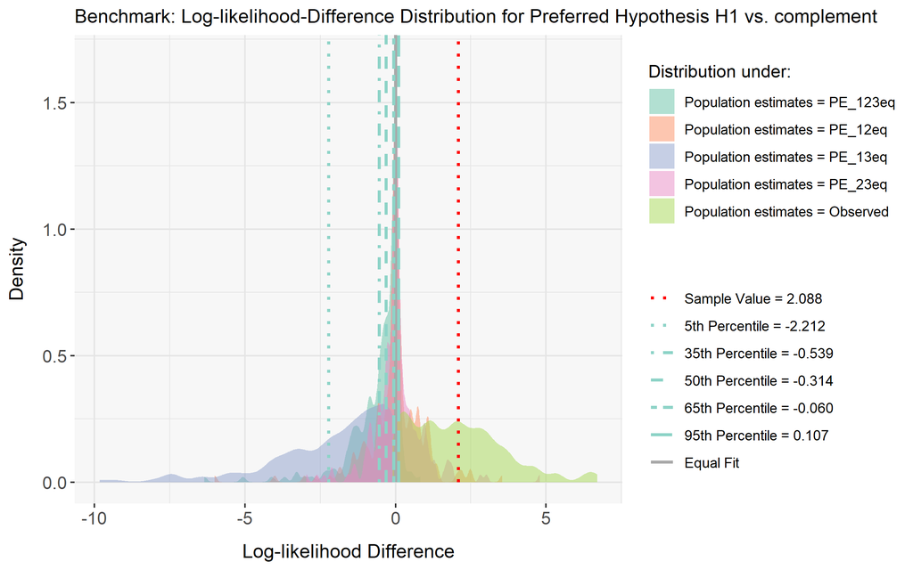

```r
plot(benchmarks_1c_allpos_200, output_type = "ld") # x_lim = c(<min>, <max>)
```

```r
#
# ratio of loglik weights
#print(benchmarks_1c_allpos_200, output_type = "rlw") # R file
print(benchmarks_1c_allpos_200, output_type = "rlw", color = FALSE) # Rmd file
```

```
##
## Benchmark Results
## ----------------------------------------------------------------------
## Preferred Hypothesis: H1
## Error probability Preferred Hypothesis vs. Complement: 0.051
## Sample Size: 600
## Number of Parameters: 3
## Population Estimates (PE):
##              D1     D2     D3
## PE_123eq  0.634  0.634  0.634
## PE_12eq   0.755  0.755  0.392
## PE_13eq   0.755  0.589  0.755
## PE_23eq   0.921  0.491  0.491
## Observed  0.921  0.589  0.392
##
##
## ===========================================================================================
## Benchmark: Percentiles of Ratio-of-log-likelihood-weights for the Preferred Hypothesis 'H1'
## -------------------------------------------------------------------------------------------
## Population estimates = PE_123eq
##                   Sample 5%    35%   50%   65%   95%
## H1 vs. complement 8.070  0.110 0.583 0.731 0.942 1.113
##
## Population estimates = PE_12eq
##                   Sample 5%    35%   50%   65%   95%
## H1 vs. complement 8.070  0.245 0.920 1.000 1.112 3.156
##
## Population estimates = PE_13eq
##                   Sample 5%    35%   50%   65%   95%
## H1 vs. complement 8.070  0.002 0.094 0.211 0.374 0.988
##
## Population estimates = PE_23eq
##                   Sample 5%    35%   50%   65%   95%
## H1 vs. complement 8.070  0.359 0.933 1.001 1.105 3.596
##
## Population estimates = Observed
##                   Sample 5%    35%   50%   65%    95%
## H1 vs. complement 8.070  1.069 3.270 6.802 12.787 138.242
```

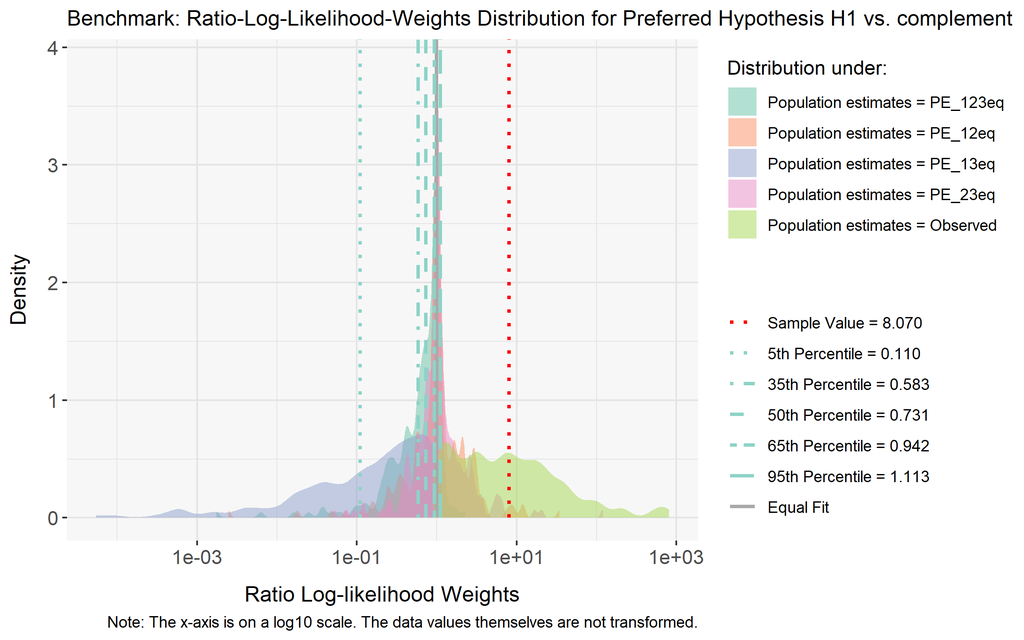

```r
#plot(benchmarks_1c_allpos_200, output_type = "rlw") # x_lim = c(<min>, <max>)
plot(benchmarks_1c_allpos_200, output_type = "rlw", log_scale = TRUE)
```

In this example with a higher sample size, the sample difference in log-likelihood values and the sample ratio of log-likelihood weights are higher than the 95th percentile of the corresponding benchmarks (for all null populations; see the benchmarks output table). Based on this, we conclude that the log-likelihood values of $H_1$ and its complement are not close. Thus, there is no support for a boundary hypothesis, only for $H_1$. In that case, we can inspect the height of the support via the GORIC(A) benchmarks (as was done in a previous section).

[^1]: Note that the benchmarks are based on the GORICA, not GORIC. Therefore, in case you used the GORIC, the reported sample value in the benchmark output may differ somewhat from your finding (in the goric output). For those interested: This has to do with using a different scaling of the covariance matrix; namely, dividing by N vs N-1.